# Can a 10-euro sensor replace a 100,000-euro analyser? Calibrating low-cost air quality sensors

## 2. What does the air look like, and what do the sensors respond to?

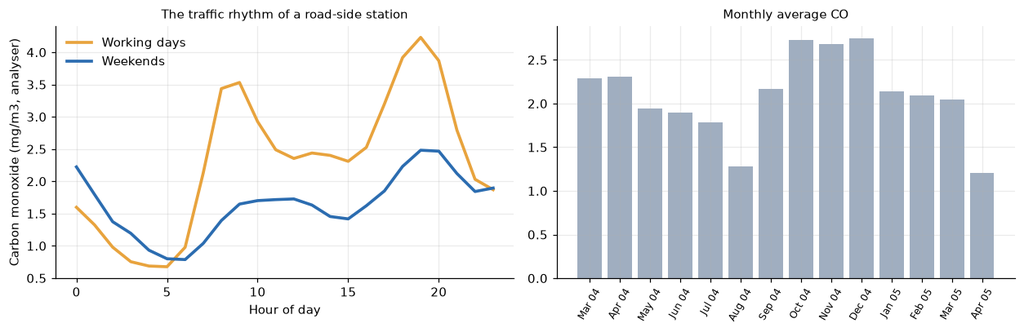

```python
air["hour"] = air.index.hour
air["weekend"] = air.index.dayofweek >= 5
profile = air.groupby(["weekend", "hour"]).CO.mean().unstack(0)
month_means = air.CO.resample("MS").mean()
fig, axes = plt.subplots(1, 2, figsize=(11.5, 3.8))
axes[0].plot(profile.index, profile[False], color=AMBER, lw=2.4, label="Working days")
axes[0].plot(profile.index, profile[True], color=BLUE, lw=2.4, label="Weekends")
axes[0].set_xlabel("Hour of day")
axes[0].set_ylabel("Carbon monoxide (mg/m3, analyser)")
axes[0].set_title("The traffic rhythm of a road-side station", fontsize=10)
axes[0].legend(frameon=False)
axes[1].bar(month_means.index.strftime("%b %y"), month_means.values, color=GREY)
axes[1].tick_params(axis="x", rotation=60, labelsize=8)
axes[1].set_title("Monthly average CO", fontsize=10)
fig.tight_layout()
plt.show()
```

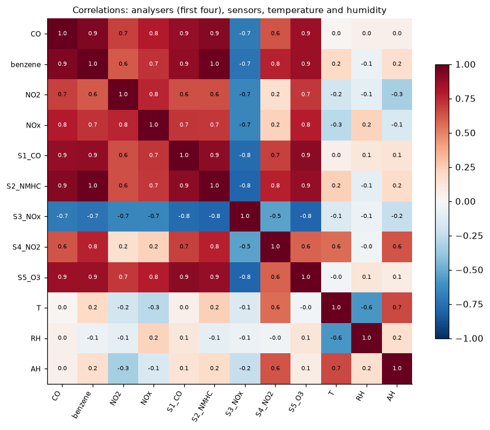

```python
corr = air[REFERENCE[:4] + SENSORS + WEATHER].corr()
fig, ax = plt.subplots(figsize=(8, 6.6))
im = ax.imshow(corr.values, cmap="RdBu_r", vmin=-1, vmax=1)
ax.set_xticks(range(len(corr)), corr.columns, rotation=60, ha="right", fontsize=8)
ax.set_yticks(range(len(corr)), corr.columns, fontsize=8)
for i in range(len(corr)):
    for j in range(len(corr)):
        ax.text(j, i, f"{corr.values[i, j]:.1f}", ha="center", va="center", fontsize=6.5,
                color="white" if abs(corr.values[i, j]) > 0.7 else "black")
ax.grid(False)
ax.set_title("Correlations: analysers (first four), sensors, temperature and humidity", fontsize=10)
fig.colorbar(im, ax=ax, shrink=0.75)
fig.tight_layout()
plt.show()
```

Every cheap sensor is strongly tied to the gases (the CO sensor `S1_CO` correlates 0.88 with carbon monoxide), but they also correlate with **each other** because they all follow the same traffic. That is helpful (a sensor for one gas carries information about another) and a trap (a model can lean on the wrong sensor). Note also that `benzene` correlates 0.98 with the NMHC sensor, so tightly that it looks like an almost direct function of that sensor. That makes it an easy target, so carbon monoxide is the main one here.